# Assignment3

2023-10-23

## Assignment 3 - Using SQL in R

- Connecting with SQL server management studio
- 1st step: install RODBC package for SQL connection
- Execute: install.packages(“RODBC”)
- This statement gives errors when run in the markdown file but should be executed before running it.
- 2nd step: load the RODBC library

```r
library(RODBC)
```

- 3rd step: list the connection
- Syntax: variable_name <- “odbcConnectionName”, rows_at_time = 1)

```r
db_conn <- odbcConnect("myDatabase", rows_at_time = 1)
```

- 4th step: write the query
- syntax: queryName <- “SQL query goes here”

#### Query 1: Sales by Region

```r
regionSalesQuery <- "select st.[Group]    as Region,
                            count(*)      as OrderCount,
                            sum(TotalDue) as TotalSales
                       from Sales.Customer         c,
                            Sales.SalesOrderHeader sh,
                            Sales.SalesTerritory   st
                       where sh.CustomerID = c.CustomerID
                         and c.TerritoryID = st.TerritoryID
                       group by st.[Group]
                       order by st.[Group]"
```

- 5th step: Load query results into dataframe

```r
regionSalesData <- sqlQuery(db_conn,
                            regionSalesQuery,
                            stringsAsFactors = FALSE)
```

#### Query 2: Sales and Profit by Product Model

```r
productProfitQuery <-"select pm.Name as Product,
                             sum(sod.LineTotal) / 1000 as Sales,
                             (sum(sod.LineTotal)
                                - sum(sod.OrderQty
                                        * p.StandardCost)) / 1000 as Profit
                        from Sales.SalesOrderDetail  sod,
                             Production.Product      p,
                             Production.ProductModel pm
                        where sod.ProductID    = p.ProductID
                          and p.ProductModelID = pm.ProductModelID
                        group by pm.name
                        order by Profit desc"
```

- Load query results into dataframe

```r
productProfitData <- sqlQuery(db_conn,
                              productProfitQuery,
                              stringsAsFactors = FALSE)
```

#### Visualize Sales by Region data (query 1) in pie chart

- Load ggplot library

```r
library(ggplot2)
```

- Calculate percentage of sales per region

```r
regionSalesData$fraction <- regionSalesData$TotalSales / sum(regionSalesData$TotalSales)
regionSalesData$percentage <- round(regionSalesData$fraction * 100)
```

- Plot pie chart of sales by regions
- Plot created in three steps for ease of understanding and debugging

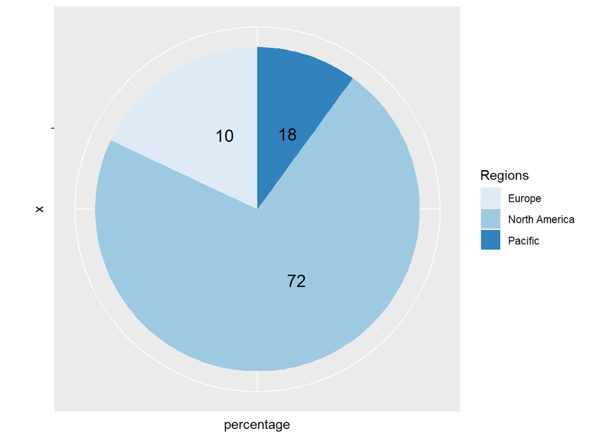

```r
bp <- ggplot(regionSalesData, aes(x="", y=percentage, fill=Region)) +
        geom_bar(width=1, stat = "identity")

pie <- bp + coord_polar("y", start=0)

pie + scale_fill_brewer("Regions") +
  theme(axis.text.x=element_blank()) +
  geom_text(aes(y = percentage/3 + c(0, cumsum(percentage)[-length(percentage)]),
                label = percentage), size=5)
```

#### Visualize Most Profitable Product Models (query 2) in horizontal stacked bar chart

- Reduce full list of products to top 10

```r
productProfitDataTop10 <- head(productProfitData, 10)
```

- Load tidyr library

```r
library(tidyr)
```

- Rearrange query results in long tidy format for use by ggplot

```r
long_top10 <- productProfitDataTop10 %>%
  pivot_longer(cols = c("Sales", "Profit"),
               names_to = "KPI",
               values_to = "Amount" )
```

- Plot Sales and Profit by Product Model in horizontal stacked bar chart
- Plot created in two steps for ease of understanding and debugging

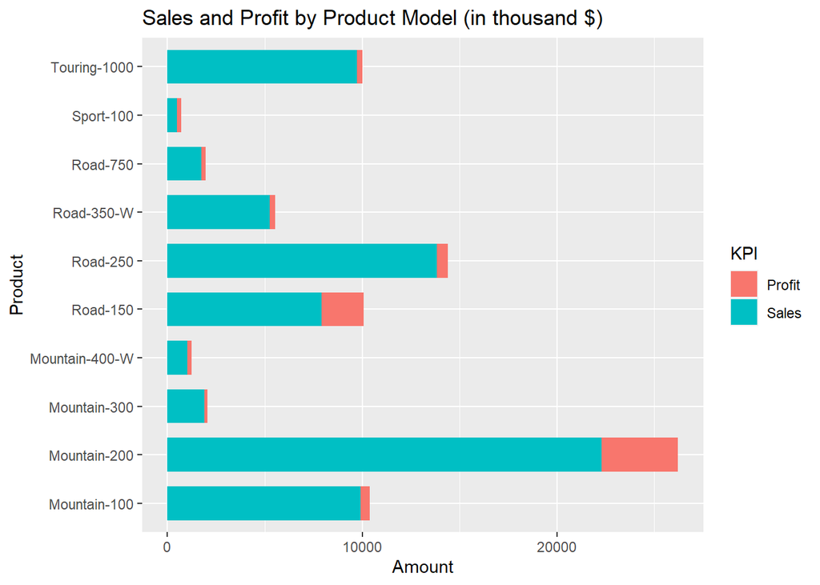

```r
p <- ggplot(long_top10, aes(x = Product, y = Amount)) +
  geom_col(aes(fill = KPI), width = 0.7) +
  labs(title = "Sales and Profit by Product Model (in thousand $)")

p + coord_flip()
```

- 6th step: close the ODBC connection

```r
odbcClose(db_conn)
```